# Session 2: Statistical Simulation and Regression

# 1. Simulation: Confidence Interval Coverage

**1.1 Initialization:** Set the true mean $\mu = 2$, sample size $n = 300$, and the number of iterations $n_{iter} = 1000$.

**1.2 Data Generation:** Generate random samples from a Continuous Uniform Distribution $X \sim U(-3, 7)$.

**1.3 CI Construction:** For each iteration, construct a 95% confidence interval for the mean $E(X) = \mu$. Determine whether the true parameter $\mu$ is contained within the interval.

**1.4 Evaluation:** Calculate the empirical coverage probability (the proportion of intervals containing $\mu$) and discuss if it aligns with the theoretical 95% level.

```r
rm(list = ls())
set.seed(123) # For reproducibility

# 1.1 Initialization
# Set the true mean, sample size, number of iterations, and significance level
mu_true <- 2
a <- -3; b <- 7
ns <- 300
n_iter <- 1000
alpha <- 0.05

# Storage vectors
means_dist <- rep(NA, n_iter)     # stores sample means
covered    <- rep(FALSE, n_iter)  # stores CI coverage result

# 1.2 ~ 1.3: Data Generation & CI Construction
# Use t critical value to construct a 95% confidence interval
cutoff <- qt(1 - alpha/2, df = ns - 1)

i <- 1
for (i in 1:n_iter) {
  # Generative model: U(-3, 7)
  mysample    <- runif(ns, a, b)

  # Compute sample mean and sample standard deviation
  sample_mean <- mean(mysample)
  sample_sd   <- sd(mysample)

  # Store sample mean for later analysis
  means_dist[i] <- sample_mean

  # Confidence Interval
  (lower <- sample_mean - cutoff * (sample_sd / sqrt(ns)))
  (upper <- sample_mean + cutoff * (sample_sd / sqrt(ns)))

  # Check whether the true mean is inside the interval
  covered[i] <- (mu_true > lower) & (mu_true < upper)
}

# 1.4 Evaluation
(coverage_uniform <- sum(covered) / n_iter)
mean(covered)
cat("1.4 Empirical Coverage Probability (Uniform):", coverage_uniform, "\n\n")

### Alternative way
set.seed(101)
# Generate all n_iter samples at once as a matrix (rows = iterations, cols = observations)
samps <- matrix(runif(ns * n_iter, a, b), nrow = n_iter, ncol = ns)
dim(samps)
# Compute row-wise sample means and standard errors
x.bars  <- apply(samps, 1, mean)
se.xbar <- apply(samps, 1, sd) / sqrt(ns)
# Proportion of CIs that contain the true mean (empirical coverage)
mean(((x.bars - cutoff * se.xbar) <= mu_true) & ((x.bars + cutoff * se.xbar) >= mu_true))
```

**Results**

```
## coverage_uniform: 0.96
```

```
## mean(covered): 0.96
```

```
## 1.4 Empirical Coverage Probability (Uniform): 0.96
```

```
## dim(samps): 1000 300
```

```
## Alternative Coverage: 0.949
```

# 2. Properties of Estimators: Bias and MSE

**2.1 Sampling Distribution:** Visualize the distribution of the 1000 sample means using a histogram. Compare the empirical mean of the sample means with the true $\mu=2$.

**2.2 Variance Analysis:** Compare the empirical variance of the sample means with the theoretical variance $\frac{\sigma^{2}}{n}$. Note: For $X \sim U(a,b)$, $V(X) = \sigma^{2} = \frac{(b-a)^{2}}{12}$.

**2.3 Bias Calculation:** Calculate both the absolute **Bias** $\left(E[\hat{\mu}] - \mu\right)$ and the **Relative Bias** $\left(\frac{\text{Bias}}{\mu}\right)$.

**2.4 Error Metrics:** Calculate the **Mean Squared Error (MSE)** $\left(E[(\hat{\mu}-\mu)^{2}]\right)$ and the **Relative Root Mean Squared Error (RRMSE)** $\left(\frac{\sqrt{\text{MSE}}}{\mu}\right)$.

```r
# 2.1 Sampling Distribution - 2.2 Variance Analysis
hist(means_dist, main = "Distribution of Sample Means (Uniform)", col = "lightblue")
emp_mean <- mean(means_dist) # Compare empirical mean with true mean

# Compare empirical variance with theoretical variance sigma^2 / n
emp_var  <- var(means_dist)        # observed variance of sample means across iterations
theo_var <- ((b - a)^2 / 12) / ns # theoretical variance of X-bar = Var(Uniform) / n = (b-a)^2/12 / n

cat("Empirical Mean vs True Mu:", emp_mean, "vs", mu_true, "\n")
cat("Empirical Var vs Theo Var:", emp_var, "vs", theo_var, "\n")

# 2.3 Bias Calculation
# Compute absolute bias and relative bias
bias     <- emp_mean - mu_true
rel_bias <- bias / mu_true
cat("Bias:", bias, "| Relative Bias:", rel_bias, "\n")

# 2.4 Error Metrics
mse    <- mean((means_dist - mu_true)^2)
r_rmse <- sqrt(mse) / mu_true
cat("MSE:", mse, "| Relative RMSE:", r_rmse, "\n")
```

**Results**

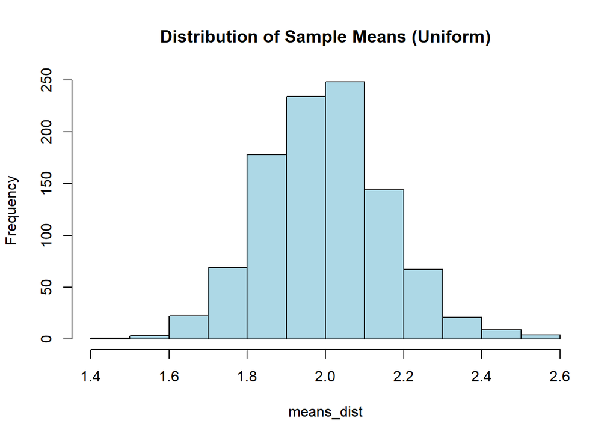

```
## Empirical Mean vs True Mu: 1.99922 vs 2
```

```
## Empirical Var vs Theo Var: 0.0256188 vs 0.02777778
```

```
## Bias: -0.0007797106 | Relative Bias: -0.0003898553
```

```
## MSE: 0.02559379 | Relative RMSE: 0.07999029
```

# 3. Simulation under Normality

**3.1 Distributional Shift:** Repeat the procedures from Tasks 1 and 2, but generate data from a Normal Distribution $N(5, 2^{2})$.

**3.2 Comparison:** Observe how the coverage probability and error metrics behave when the population distribution is perfectly normal versus uniform.

```r
# 3.1 Distributional Shift
# Repeat Tasks 1 and 2 using Normal(5, 2^2)
mu_norm    <- 5
sigma_norm <- 2

means_dist_n <- rep(NA, n_iter)    # stores sample means
covered_n    <- rep(FALSE, n_iter) # stores CI coverage result

for (i in 1:n_iter) {
  # Generate one random sample from Normal(5, 2^2)
  mysample <- rnorm(ns, mean = mu_norm, sd = sigma_norm)

  # Compute sample statistics
  s_mean <- mean(mysample)
  s_sd   <- sd(mysample)

  # Store the sample mean
  means_dist_n[i] <- s_mean

  # Construct 95% confidence interval
  lower <- s_mean - cutoff * (s_sd / sqrt(ns))
  upper <- s_mean + cutoff * (s_sd / sqrt(ns))

  # Check whether the true mean is inside the interval
  covered_n[i] <- (mu_norm > lower) & (mu_norm < upper)
}

cat("\n--- Normal Distribution Results ---\n")
coverage_normal <- sum(covered_n) / n_iter
cat("Coverage:", coverage_normal, "\n")

# Visualize the distribution of the sample means
hist(means_dist_n,
     main   = "Distribution of Sample Means (Normal)",
     xlab   = "Sample Mean",
     col    = "lightgreen",
     border = "white")

# Compare the empirical mean with the true mean
emp_mean_n <- mean(means_dist_n)
cat("3.2 Empirical Mean vs True Mu:", emp_mean_n, "vs", mu_norm, "\n")

# Compare the empirical variance with the theoretical variance
emp_var_n  <- var(means_dist_n)
theo_var_n <- (sigma_norm^2) / ns
cat("3.2 Empirical Variance vs Theoretical Variance:", emp_var_n, "vs", theo_var_n, "\n")

# Compute the bias and relative bias
bias_n     <- emp_mean_n - mu_norm
rel_bias_n <- bias_n / mu_norm
cat("3.2 Bias:", bias_n, "\n")
cat("3.2 Relative Bias:", rel_bias_n, "\n")

# Compute the MSE and relative RMSE
mse_n    <- mean((means_dist_n - mu_norm)^2)
r_rmse_n <- sqrt(mse_n) / mu_norm
cat("3.2 MSE:", mse_n, "\n")
cat("3.2 Relative RMSE:", r_rmse_n, "\n\n")

# 3.2 Comparison
# Compare the results from Uniform and Normal cases
cat("3.2 Comparison: Uniform vs Normal\n")
cat("Coverage:", coverage_uniform, "vs", coverage_normal, "\n")
cat("Bias:", bias, "vs", bias_n, "\n")
cat("Relative Bias:", rel_bias, "vs", rel_bias_n, "\n")
cat("MSE:", mse, "vs", mse_n, "\n")
cat("Relative RMSE:", r_rmse, "vs", r_rmse_n, "\n\n")
```

**Results**

```
## Coverage (Normal): 0.957
```

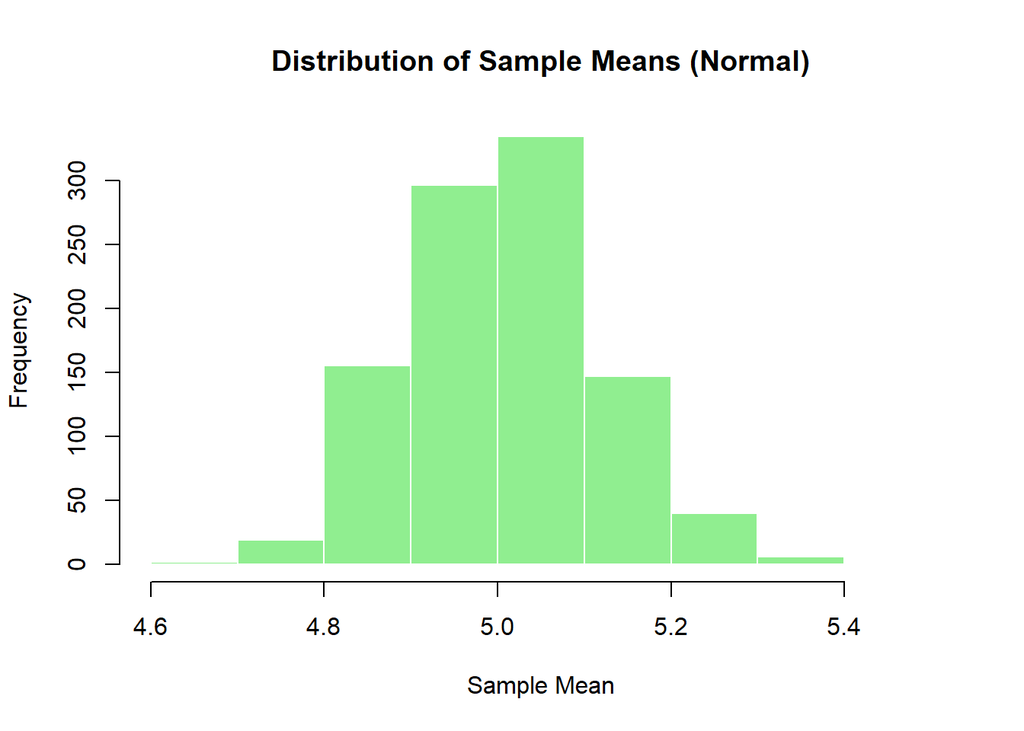

```
## Empirical Mean vs True Mu: 5.006727 vs 5
```

```
## Empirical Var vs Theo Var: 0.01248046 vs 0.01333333
```

```
## Bias: 0.006727075 | Relative Bias: 0.001345415
```

```
## MSE: 0.01251323 | Relative RMSE: 0.02237251
```

Uniform vs Normal Comparison

| Metric | Uniform | Normal |
| --- | --- | --- |
| Coverage | 0.960000 | 0.957000 |
| Bias | -0.000780 | 0.006727 |
| Relative Bias | -0.000390 | 0.001345 |
| MSE | 0.025594 | 0.012513 |
| Relative RMSE | 0.079990 | 0.022373 |

# 4. Simple Linear Regression (SLR)

**4.1 Generative Model:** Create a simulation dataset ($n = 20$) based on the model $Y = \beta_{0} + \beta_{1}X + \epsilon$, where $\boldsymbol{\beta} = [\beta_{0}, \beta_{1}]^{T} = [2, 3]^{T}$, $X \sim U(0,10)$, and $\epsilon \sim N(0, 10^{2})$.

**4.2 Estimation:** Estimate the coefficients using the built-in lm() function.

- Manually calculate the OLS estimators $\hat{\beta}_{1} = \frac{Cov(X,Y)}{Var(X)}$ and $\hat{\beta}_{0} = \bar{Y} - \hat{\beta}_{1}\bar{X}$ to verify the results.

**4.3 Visualization:** Plot the data points and overlay the fitted regression line.

```r
set.seed(101)

# 4.1 Generative Model
# Create data from Y = beta0 + beta1*X + error
n_reg     <- 20
beta_true <- c(2, 3) # Intercept, Slope
sig_eps   <- 10      # standard deviation of error

X   <- runif(n_reg, min = 0, max = 10)
eps <- rnorm(n_reg, mean = 0, sd = sig_eps)
Y   <- beta_true[1] + beta_true[2] * X + eps

# 4.2 Estimation using lm()
fit <- lm(Y ~ X)
cat("\n--- SLR Estimates (lm) ---\n")
print(fit$coefficients)

# Verify the built-in results with manual formulas
b1_hat <- cov(X, Y) / var(X)
b0_hat <- mean(Y) - b1_hat * mean(X)
cat("Manual Estimates: Intercept =", b0_hat, ", Slope =", b1_hat, "\n")

# 4.3 Visualization
# Plot the data points and overlay the fitted regression line
plot(X, Y, pch = 21, bg = "red", main = "Simple Linear Regression Simulation")
abline(fit, lwd = 2, col = "blue")
```

**Results**

```
## --- SLR Estimates (lm) ---
```

```
## (Intercept)           X
##    2.005749    2.515358
```

```
## Manual Estimates: Intercept = 2.005749 , Slope = 2.515358
```

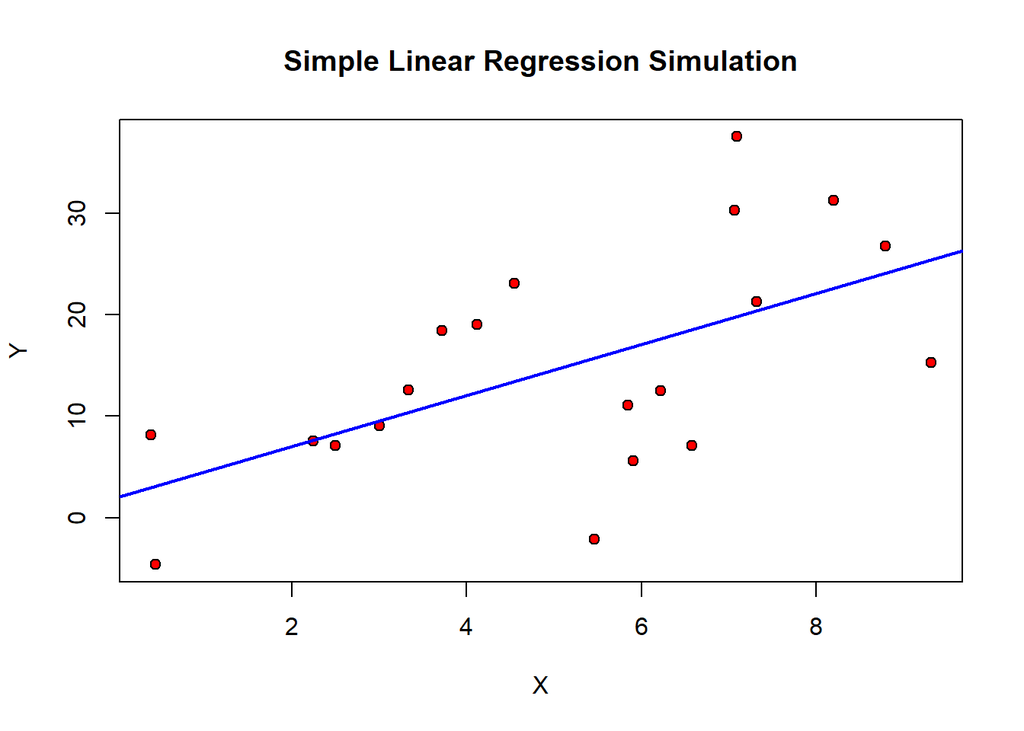

*Session 2 | Statistical Simulation and Regression*